# Assignment_9_Akshat_Sinha

$\textbf{Problem 1.}$ Run the original word2vec.exe and create embeddings from text8.zip file as described in lecture notes. Demonstrate that demo-word.sh works by finding similar word to two of words of your choice. (15%)

$\textbf{Steps and Code:}$

1. Run demo-word.sh. It downloads text8.zip from http://mattmahoney.net/dc/text8.zip and runs word2vec.exe. 'word2vec.exe' runs the continuous-bag-of words model with dimensionality of 200, the size of the context window of 8, using negative sampling algorithm with threshold of 1e-4 to produce embeddings from the corpus of words in text8.zip. The embeddings are saved in file vectors.bin.

$ ./demo-word.sh make: Nothing to be done for 'all'. --------------------------------------------------------------------------------------------------- Note that for the word analogy to perform well, the model should be trained on much larger data set Example input: paris france berlin --------------------------------------------------------------------------------------------------- Starting training using file text8 Vocab size: 71291 Words in train file: 16718843 Alpha: 0.000005 Progress: 100.10% Words/thread/sec: 83.93k real 12m50.744s user 49m59.656s sys 0m2.140s

2. Call distance.exe with 'vectors.bin' as the argument. This script outputs the most similar words from the corpus based on cosine distance. I have used the words 'sincere' and 'politics' for my demo.

$ ./distance vectors.bin  
Enter word or sentence (EXIT to break): sincere

Word: sincere Position in vocabulary: 16291

```
                                          Word       Cosine distance
```

```
                                      believer              0.508035
                                    conscience              0.484672
                                         faith              0.471297
                                     salvation              0.470599
                                    repentance              0.463140
                                   selfishness              0.454214
                                     rejection              0.446344
                                        unduly              0.442633
                                         piety              0.442080
                                predestination              0.441922
                                       provoke              0.440755
                                       worldly              0.437072
                                        virtue              0.436129
                                      kindness              0.435065
                                   forgiveness              0.434058
                                     brotherly              0.429010
                                       honesty              0.425954
                                     sincerity              0.425922
                                         truth              0.421282
                                    expressing              0.421233
                                       despair              0.420694
                                 righteousness              0.419236
                                   affirmation              0.417097
                                      devotion              0.415489
                                       desires              0.414598
                                      humility              0.413941
                                       virtues              0.413085
                                    compassion              0.412717
                                   benevolence              0.411440
                                         grace              0.409755
                                      feelings              0.407946
                                        hatred              0.404597
                                       wronged              0.403363
                                   realisation              0.402651
                                      salvific              0.402290
                                    absolution              0.400742
                                         guilt              0.400522
                                      sympathy              0.400306
                                     justified              0.399118
                                       impious              0.398012
```

Enter word or sentence (EXIT to break): politics

Word: politics Position in vocabulary: 823

```
                                          Word       Cosine distance
```

```
                                     political              0.657083
                              multiculturalism              0.498159
                                    radicalism              0.482741
                             constitutionalism              0.473870
                                      ideology              0.469087
                                     sociology              0.466884
                                       liberal              0.461836
                                  jeffersonian              0.453224
                                    multiparty              0.451197
                                    democratic              0.450226
                                       affairs              0.440730
                                     democracy              0.440405
                                 republicanism              0.434517
                                      religion              0.432421
                                  expansionism              0.430243
                                        policy              0.429431
                                   nationalism              0.428052
                               democratisation              0.421833
                                     reformist              0.420629
                                    federalist              0.419108
                                         party              0.416572
                                    opposition              0.411188
                                       leftist              0.410280
                                          whig              0.407559
                                   colonialism              0.405823
                                    ecuadorean              0.402198
                                    jacksonian              0.400372
                                    government              0.399792
                                      centrist              0.399504
                                      leanings              0.399229
                                    figurehead              0.398373
                                       economy              0.398162
                              internationalism              0.397347
                                   realpolitik              0.397047
                                       dissent              0.393553
                              environmentalism              0.393414
                                    guatemalan              0.392742
                                    separatism              0.389713
                              authoritarianism              0.387868
                                      activism              0.387842
```

$\textbf{Problem 2.}$ Use word-analogy.sh script to rectify error I made on slide 43 of the lecture notes. I asked for analogy amongst words: king man woman. I should have asked for words: man king woman. Does the result makes sense and is it in agreement with the vector similarities we advertised. (20%)

$\textbf{Steps and Code:}$

1. Call 'word-analogy.exe' with 'vectors.bin' as argument. This allows us to generate word analogies from vectors.bin file generated in previous problem. 2. Enter 'man king woman' to get the closest matching words for the analogy 'man:king::woman:?'. We find that 'queen' comes out at top, which is expected. This result is in agreement with the vector similarities described in the lecture.

$ ./word-analogy vectors.bin Enter three words (EXIT to break): man king woman Word: man Position in vocabulary: 243 Word: king Position in vocabulary: 187 Word: woman Position in vocabulary: 1012 Word Distance ------------------------------------------------------------------------ queen 0.584235 montferrat 0.538089 anjou 0.502499 heiress 0.490614 marries 0.486458 daughter 0.486101 betrothed 0.480538 infanta 0.477006 isabella 0.472338 sibylla 0.470298 vii 0.467301 son 0.458748 matilda 0.457915 burgundy 0.457301 yolande 0.455971 throne 0.454726 prince 0.450469 consort 0.449910 melisende 0.449685 elizabeth 0.445980 aragon 0.445977 eustace 0.441950 aquitaine 0.435223 valois 0.432736 sigismund 0.431564 gascony 0.430900 wife 0.428418 urraca 0.427811 brienne 0.427661 wedded 0.427367 barons 0.424761 claimant 0.422896 ahasuerus 0.422823 savoy 0.422737 regent 0.420663 sobieski 0.420356 vermandois 0.419769 sahle 0.419284 philippa 0.418436 heir 0.418333

$\textbf{Problem 3.}$ Use demo-phrases.sh script to embed two-word phrases. Once the embedding is done, examine the most similar phrases to two phrases: london_bridge and red_wine. (20%)

$\textbf{Steps and Code:}$

1.Run 'demo-phrases.sh' to train the model with a corpus of phrases.

$ ./demo-phrases.sh make: Nothing to be done for 'all'. --2018-04-07 23:47:53-- http://www.statmt.org/wmt14/training-monolingual-news-c rawl/news.2012.en.shuffled.gz Resolving www.statmt.org (www.statmt.org)... 129.215.197.184 Connecting to www.statmt.org (www.statmt.org)|129.215.197.184|:80... connected. HTTP request sent, awaiting response... 200 OK Length: 786717767 (750M) [application/x-gzip] Saving to: ‘news.2012.en.shuffled.gz’ news.2012.en.shuffl 100%[===================>] 750.27M 4.45MB/s in 4m 59s 2018-04-07 23:52:52 (2.51 MB/s) - ‘news.2012.en.shuffled.gz’ saved [786717767/78 6717767] Starting training using file news.2012.en.shuffled-norm0 Words processed: 296900K Vocab size: 33198K Vocab size (unigrams + bigrams): 18838711 Words in train file: 296901342 Words written: 296900K real 37m7.760s user 23m23.453s sys 12m34.062s Starting training using file news.2012.en.shuffled-norm0-phrase0 Words processed: 280500K Vocab size: 38761K Vocab size (unigrams + bigrams): 21728781 Words in train file: 280513979 Words written: 280500K real 37m30.823s user 22m50.890s sys 13m42.546s Starting training using file news.2012.en.shuffled-norm1-phrase1 Vocab size: 681320 Words in train file: 283545447 Alpha: 0.000005 Progress: 100.00% Words/thread/sec: 124.39k real 439m0.396s user 574m40.187s sys 1m20.453s

2. Enter 'london_bridge' to get the most similar words/phrases by cosine distance. We find 'liverpool_street', 'thames' and 'underground_station' at top.

Enter word or sentence (EXIT to break): london_bridge

Word: london_bridge Position in vocabulary: 44297

```
                                          Word       Cosine distance
```

```
                              liverpool_street              0.637184
                                        thames              0.611050
                           underground_station              0.606648
                                  king's_cross              0.600436
                                  tower_bridge              0.592890
                                   kings_cross              0.579351
                                central_london              0.573142
                                  jubilee_line              0.564611
                            st_pancras_station              0.563033
                                 cannon_street              0.556554
                                  tube_station              0.556343
                                       aldgate              0.555779
                                  river_thames              0.554985
                              trafalgar_square              0.546115
                       docklands_light_railway              0.544713
                                     southwark              0.540538
                                 charing_cross              0.533210
                                   marble_arch              0.532528
                             piccadilly_circus              0.530807
                            london_underground              0.529245
                                      moorgate              0.526509
                      st_pancras_international              0.525059
                                   city_centre              0.524259
                                       holborn              0.523520
                           victoria_embankment              0.522622
                                  central_line              0.522478
                              battersea_bridge              0.520968
                                  olympic_park              0.515492
                            westminster_bridge              0.515126
                                olympic_venues              0.514914
                                 tube_stations              0.511410
                                     crossrail              0.510702
                                  canary_wharf              0.509836
                                russell_square              0.507313
                             hungerford_bridge              0.504282
                               old_vic_tunnels              0.503995
                                    london_eye              0.503620
                                 chancery_lane              0.502560
                                      bakerloo              0.496537
                                          tram              0.496445
```

3. Enter 'red-wine' to get the most similar words/phrases by cosine distance. We find 'white_wine', 'wine' and 'astringents' at top, which makes sense.

Enter word or sentence (EXIT to break): red_wine

Word: red_wine Position in vocabulary: 17150

```
                                          Word       Cosine distance
```

```
                                    white_wine              0.672334
                                          wine              0.600739
                                   astringents              0.578001
                                         drink              0.565842
                                        lillet              0.564723
                                 pint_ml_stock              0.562248
                                       cup_dry              0.560049
                                   tonic_water              0.559200
                                   grape_juice              0.553419
                               cranberry_juice              0.551464
                              antioxidant_rich              0.550222
                                     red_meats              0.547388
                         contains_antioxidants              0.546023
                             drinking_red_wine              0.545326
                                   stroke_risk              0.544932
                                   resveratrol              0.544157
                                      sloe_gin              0.542655
                                      digestif              0.540328
                                        prunes              0.539998
                                   steak_sauce              0.537426
                                        aperol              0.530161
                            blood_orange_juice              0.529423
                                  soft_tannins              0.529031
                                        bottle              0.528744
                                      prosecco              0.527103
                                      calvados              0.525403
                                      muscadet              0.525041
                                     red_wines              0.524408
                                     green_tea              0.524231
                                 dessert_wines              0.522405
                                       snifter              0.520978
                                      highball              0.520755
                              tablespoons_rice              0.520585
                                     warm_milk              0.517657
                              balsamic_vinegar              0.517653
                                      aperitif              0.517180
                                fortified_wine              0.516745
                                pink_champagne              0.514472
                                  dessert_wine              0.514456
                               juniper_berries              0.514000
```

$\textbf{Problem 4}$ Use the following Gensim code to transform binary file vectors.bin into a text file, vectors.txt.

```
from gensim.models import KeyedVectors
model = KeyedVectors.load_word2vec_format('vectors.bin', binary=True)
# C text format
model.save_word2vec_format('vectors.txt', binary=False)
```

Tell us what is the volume of new file when compared with the C binary file vectors.bin. Examine the file and locate vectors for words: queen, king, woman and man. Present for us the first 10 coordinates of each vector. (20%)

$\textbf{Steps and Code:}$

1. Use the code to produce 'vectors.txt' from 'vectors.bin' produced from Problem 1.

```python
from gensim.models import KeyedVectors
model = KeyedVectors.load_word2vec_format('vectors.bin', binary=True)
# C text format
model.save_word2vec_format('vectors.txt', binary=False)
```

```
2018-04-08 00:06:55,655 : INFO : loading projection weights from vectors.bin
2018-04-08 00:06:57,149 : INFO : loaded (71291, 200) matrix from vectors.bin
2018-04-08 00:06:57,213 : INFO : storing 71291x200 projection weights into vectors.txt
```

2. We find that vectors.txt is three times the size of vectors.txt at 159 MB and 57 MB respectively.

$ ls -al -rwx------+ 1 asinha asinha 57704809 Apr 7 21:50 vectors.bin -rwxrwx---+ 1 Administrators asinha 159229581 Apr 8 00:07 vectors.txt

```python
model = KeyedVectors.load_word2vec_format('vectors.txt', binary=False)
```

```
2018-04-08 00:08:07,448 : INFO : loading projection weights from vectors.txt
2018-04-08 00:08:26,278 : INFO : loaded (71291, 200) matrix from vectors.txt
```

```python
print(model.get_vector('queen')[0:10])
print(model.get_vector('king')[0:10])
print(model.get_vector('woman')[0:10])
print(model.get_vector('man')[0:10])
```

```
[ 0.6221384  -2.381173   -0.62738276 -1.0975784   1.2373395  -3.1950328
 -0.74022526  0.47273895 -1.1066034  -1.5091859 ]
[-1.8954808  -0.8628662  -2.0278444  -0.5545433   2.951458   -1.4985704
 -2.6483643  -2.0140924  -0.97132504 -1.605231  ]
[-0.58591014 -1.0758336  -1.1054654  -2.7096047   0.16424485  0.6074105
 -0.13503285  2.3363764   3.0286949  -1.4967729 ]
[ 1.4167926  -0.7298542  -2.2284133  -1.2658012   1.0197504  -0.02355143
  1.0337201   0.6177318   1.4861876   0.45655224]
```

$\textbf{Problem 5}$ Run the code in Embeddings section of the provided Jupyter notebook. Notice that the embeddings (vector coordinates) get deposited in Numpy array called final_embeddings. Tell us what are the dimensions of that array? Could you create a panda data frame which would, besides those embeddings, also contain words corresponding to vectors in final_embeddings array. Export that panda as a .txt file or a .scv file and compare vectors in exported file with vectors for words; king, queen, man and woman in file vectors.txt you created in the previous problem (25%)

$\textbf{Code and Steps:}$

1. Run the embeddings section of the code as provided in the Jupyter notebook.

```python
# To support both python 2 and python 3
from __future__ import division, print_function, unicode_literals

# Common imports
import tensorflow as tf
import numpy as np
import os

# to make this notebook's output stable across runs
def reset_graph(seed=42):
    tf.reset_default_graph()
    tf.set_random_seed(seed)
    np.random.seed(seed)

# To plot pretty figures

import matplotlib
import matplotlib.pyplot as plt
%matplotlib inline
plt.rcParams['axes.labelsize'] = 14
plt.rcParams['xtick.labelsize'] = 12
plt.rcParams['ytick.labelsize'] = 12
plt.show()
# Where to save the figures
PROJECT_ROOT_DIR = r"/home/ec2-user/Assignment/"
CHAPTER_ID = "rnn"

def save_fig(fig_id, tight_layout=True):
    path = os.path.join(PROJECT_ROOT_DIR, "images", CHAPTER_ID, fig_id + ".png")
    print("Saving figure", fig_id)
    if tight_layout:
        plt.tight_layout()
    plt.savefig(path, format='png', dpi=300)
```

```python
from six.moves import urllib

import errno
import os
import zipfile

WORDS_PATH = "datasets/words"
WORDS_URL = 'http://mattmahoney.net/dc/text8.zip'

def mkdir_p(path):
    """Create directories, ok if they already exist.

    This is for python 2 support. In python >=3.2, simply use:
    >>> os.makedirs(path, exist_ok=True)
    """
    try:
        #  os.makedirs(path)
        os.makedirs(path,exist_ok=True)
    except OSError as exc:
        if exc.errno == errno.EEXIST and os.path.isdir(path):
            pass
        else:
            raise

def fetch_words_data(words_url=WORDS_URL, words_path=WORDS_PATH):
    os.makedirs(words_path, exist_ok=True)
    zip_path = os.path.join(words_path, "words.zip")
    if not os.path.exists(zip_path):
        urllib.request.urlretrieve(words_url, zip_path)
    with zipfile.ZipFile(zip_path) as f:
        data = f.read(f.namelist()[0])
    return data.decode("ascii").split()
```

```python
words = fetch_words_data()
```

```python
words[70090:70100]
len(words)
```

```
17005207
```

```python
import numpy as np
from collections import Counter

vocabulary_size = 50000

vocabulary = [("UNK", None)] + Counter(words).most_common(vocabulary_size - 1)
vocabulary = np.array([word for word, _ in vocabulary])
dictionary = {word: code for code, word in enumerate(vocabulary)}
data = np.array([dictionary.get(word, 0) for word in words])
```

```python
print(type(vocabulary))
print(vocabulary.shape)
vocabulary
print(type(dictionary))
dictionary
```

```
<class 'numpy.ndarray'>
(50000,)
<class 'dict'>
```

[output not shown]

[output cut: 946 more lines]

[output not shown]

```python
print(dictionary['king'])
print(dictionary['queen'])
print(dictionary['man'])
print(dictionary['woman'])
print(dictionary['doctor'])
print(dictionary['nurse'])
```

```
187
903
243
1012
1908
10158
```

```python
" ".join(words[:9]), data[:9]
```

```
('anarchism originated as a term of abuse first used',
 array([5242, 3084,   12,    6,  195,    2, 3136,   46,   59]))
```

```python
" ".join([vocabulary[word_index] for word_index in [5241, 3081, 12, 6, 195, 2, 3134, 46, 59]])
```

```
'belonging matrix as a term of presidency first used'
```

```python
words[255], data[255]
```

```
('that', 20)
```

```python
import random
from collections import deque

def generate_batch(batch_size, num_skips, skip_window):
    global data_index
    assert batch_size % num_skips == 0
    assert num_skips <= 2 * skip_window
    batch = np.ndarray(shape=(batch_size), dtype=np.int32)
    labels = np.ndarray(shape=(batch_size, 1), dtype=np.int32)
    span = 2 * skip_window + 1 # [ skip_window target skip_window ]
    buffer = deque(maxlen=span)
    for _ in range(span):
        buffer.append(data[data_index])
        data_index = (data_index + 1) % len(data)
    for i in range(batch_size // num_skips):
        target = skip_window  # target label at the center of the buffer
        targets_to_avoid = [ skip_window ]
        for j in range(num_skips):
            while target in targets_to_avoid:
                target = random.randint(0, span - 1)
            targets_to_avoid.append(target)
            batch[i * num_skips + j] = buffer[skip_window]
            labels[i * num_skips + j, 0] = buffer[target]
        buffer.append(data[data_index])
        data_index = (data_index + 1) % len(data)
    return batch, labels
```

```python
data_index=0
batch, labels = generate_batch(8, 2, 1)
```

```python
batch, [vocabulary[word] for word in batch]
```

```
(array([3084, 3084,   12,   12,    6,    6,  195,  195]),
 ['originated', 'originated', 'as', 'as', 'a', 'a', 'term', 'term'])
```

```python
labels, [vocabulary[word] for word in labels[:, 0]]
```

```
(array([[  12],
        [5242],
        [   6],
        [3084],
        [  12],
        [ 195],
        [   2],
        [   6]]),
 ['as', 'anarchism', 'a', 'originated', 'as', 'term', 'of', 'a'])
```

```python
import numpy as np

batch_size = 128
embedding_size = 128  # Dimension of the embedding vector.
skip_window = 1       # How many words to consider left and right.
num_skips = 2         # How many times to reuse an input to generate a label.

# We pick a random validation set to sample nearest neighbors. Here we limit the
# validation samples to the words that have a low numeric ID, which by
# construction are also the most frequent.
valid_size = 16     # Random set of words to evaluate similarity on.
valid_window = 100  # Only pick dev samples in the head of the distribution.
valid_examples = np.random.choice(valid_window, valid_size, replace=False)
num_sampled = 64    # Number of negative examples to sample.

learning_rate = 0.01
```

```python
reset_graph()

# Input data.
train_labels = tf.placeholder(tf.int32, shape=[batch_size, 1])
valid_dataset = tf.constant(valid_examples, dtype=tf.int32)
```

```python
vocabulary_size = 50000
embedding_size = 150

# Look up embeddings for inputs.
init_embeds = tf.random_uniform([vocabulary_size, embedding_size], -1.0, 1.0)
embeddings = tf.Variable(init_embeds)
```

```python
train_inputs = tf.placeholder(tf.int32, shape=[None])
embed = tf.nn.embedding_lookup(embeddings, train_inputs)
```

```python
# Construct the variables for the NCE loss
nce_weights = tf.Variable(
    tf.truncated_normal([vocabulary_size, embedding_size],
                        stddev=1.0 / np.sqrt(embedding_size)))
nce_biases = tf.Variable(tf.zeros([vocabulary_size]))

# Compute the average NCE loss for the batch.
# tf.nce_loss automatically draws a new sample of the negative labels each
# time we evaluate the loss.
loss = tf.reduce_mean(
    tf.nn.nce_loss(nce_weights, nce_biases, train_labels, embed,
                   num_sampled, vocabulary_size))

# Construct the Adam optimizer
optimizer = tf.train.AdamOptimizer(learning_rate)
training_op = optimizer.minimize(loss)

# Compute the cosine similarity between minibatch examples and all embeddings.
norm = tf.sqrt(tf.reduce_sum(tf.square(embeddings), axis=1, keepdims=True))
normalized_embeddings = embeddings / norm
valid_embeddings = tf.nn.embedding_lookup(normalized_embeddings, valid_dataset)
similarity = tf.matmul(valid_embeddings, normalized_embeddings, transpose_b=True)

# Add variable initializer.
init = tf.global_variables_initializer()
```

```python
num_steps = 10001

with tf.Session() as session:
    init.run()

    average_loss = 0
    for step in range(num_steps):
        print("\rIteration: {}".format(step), end="\t")
        batch_inputs, batch_labels = generate_batch(batch_size, num_skips, skip_window)
        feed_dict = {train_inputs : batch_inputs, train_labels : batch_labels}

        # We perform one update step by evaluating the training op (including it
        # in the list of returned values for session.run()
        _, loss_val = session.run([training_op, loss], feed_dict=feed_dict)
        average_loss += loss_val

        if step % 2000 == 0:
            if step > 0:
                average_loss /= 2000
            # The average loss is an estimate of the loss over the last 2000 batches.
            print("Average loss at step ", step, ": ", average_loss)
            average_loss = 0

        # Note that this is expensive (~20% slowdown if computed every 500 steps)
        if step % 10000 == 0:
            sim = similarity.eval()
            for i in range(valid_size):
                valid_word = vocabulary[valid_examples[i]]
                top_k = 8 # number of nearest neighbors
                nearest = (-sim[i, :]).argsort()[1:top_k+1]
                log_str = "Nearest to %s:" % valid_word
                for k in range(top_k):
                    close_word = vocabulary[nearest[k]]
                    log_str = "%s %s," % (log_str, close_word)
                print(log_str)

    final_embeddings = normalized_embeddings.eval()
```

```
Iteration: 0	Average loss at step  0 :  298.5007019042969
Nearest to many: personalized, electronegative, prized, experiencing, stringing, dhtml, jaffna, cmd,
Nearest to from: vehicle, fleurs, continuance, curt, matthias, thermally, positrons, pir,
Nearest to there: til, foix, anabaptist, seems, firewood, reactionary, expertise, operational,
Nearest to all: accountable, undertones, popes, documentaries, adsl, shehri, homilies, nurture,
Nearest to they: wettest, strasbourg, pseudocode, havoc, discredited, ammonite, cellist, andover,
Nearest to war: partitive, igbo, tiamat, freenode, overwrite, protege, pierluigi, fulfilling,
Nearest to four: valencia, markings, personnel, qing, kekul, blew, stellated, pillaging,
Nearest to history: transistor, wct, seifert, authorize, urbana, rearranging, racecar, clarinet,
Nearest to th: streetcars, compressors, crystal, quantized, arlington, assays, craving, philo,
Nearest to one: ids, malthusian, multiplies, patinkin, trolleybus, alan, mongolian, inventive,
Nearest to see: gomorrah, flavoured, manipulates, authorship, skeptic, situ, philosophiae, testimonium,
Nearest to would: render, catan, savanna, tarragona, fucked, galton, carter, historiography,
Nearest to three: bartleby, diners, yucat, substituting, labored, wads, minnie, andrei,
Nearest to into: anjouan, soot, radians, mesoamerica, tabloids, reminds, bun, autonomously,
Nearest to been: laurent, killian, computes, riches, jogging, ctus, chemotaxis, insignia,
Nearest to has: disgrace, grew, recognising, preached, defaults, tius, flocks, usta,
Iteration: 2000	Average loss at step  2000 :  132.0740223608017
Iteration: 4000	Average loss at step  4000 :  62.37627522349358
Iteration: 6000	Average loss at step  6000 :  41.728235058784485
Iteration: 8000	Average loss at step  8000 :  31.141834504961967
Iteration: 10000	Average loss at step  10000 :  25.66445340538025
Nearest to many: alp, nato, ads, the, cushitic, altaic, milne, slain,
Nearest to from: in, with, argon, fewer, categorization, of, seo, are,
Nearest to there: also, tarkovsky, romanus, consumed, tezuka, which, lowry, making,
Nearest to all: that, frau, festival, portraits, jonathan, golf, dealings, xserve,
Nearest to they: sidebands, qxd, we, unexplained, users, ankh, benedictine, dictated,
Nearest to war: kick, nine, solanas, graph, eight, cockpit, sod, brakes,
Nearest to four: one, three, nine, two, five, eight, six, zero,
Nearest to history: electrolysis, afghana, sworn, branden, antigua, milne, ampere, spoof,
Nearest to th: darker, three, shut, one, steffi, eight, four, bombers,
Nearest to one: three, nine, eight, four, five, two, six, seven,
Nearest to see: abbots, bicycle, of, dealings, organs, wasn, anniversaries, amir,
Nearest to would: abdicated, deuterostomes, should, refusal, ludovico, booming, to, secretly,
Nearest to three: one, four, eight, two, six, nine, five, seven,
Nearest to into: anodes, sixteenth, gide, kemp, spooner, to, psalms, ductile,
Nearest to been: has, valens, have, reasonably, deutschland, aussie, already, avenue,
Nearest to has: have, had, closures, getting, critics, is, in, serif,
```

2. We find that the final_embeddings produced by the code above has the shape 50,000 X 150.

```python
np.save("./my_final_embeddings.npy", final_embeddings)
print(final_embeddings.shape)
```

```
(50000, 150)
```

3. Load the generated final_embeddings.npy file. Convert it to a pandas dataframe with 'vocabulary' as the index.

```python
import numpy as np
final_embeddings = np.load("./my_final_embeddings.npy")
```

```python
import pandas as pd
e = pd.DataFrame(final_embeddings, index=vocabulary)
e.to_csv(r"./vectors_new.txt")
e.head()
```

|  | 0 | 1 | 2 | 3 | 4 | 5 | 6 | 7 | 8 | 9 | ... | 140 | 141 | 142 | 143 | 144 | 145 | 146 | 147 | 148 | 149 |
| --- | --- | --- | --- | --- | --- | --- | --- | --- | --- | --- | --- | --- | --- | --- | --- | --- | --- | --- | --- | --- | --- |
| UNK | -0.097174 | -0.071319 | 0.026561 | -0.058367 | 0.200439 | 0.008292 | -0.066678 | 0.055755 | 0.027244 | 0.096656 | ... | 0.046624 | -0.045514 | 0.064631 | 0.122665 | 0.100420 | 0.017072 | 0.024613 | 0.063482 | -0.100106 | -0.056884 |
| the | 0.063695 | -0.006514 | -0.095252 | -0.126712 | 0.023827 | -0.053248 | -0.099918 | 0.107518 | 0.119890 | 0.114966 | ... | 0.077067 | -0.100760 | -0.008488 | 0.059077 | -0.013190 | -0.000417 | 0.045537 | 0.094586 | 0.043825 | -0.063683 |
| of | 0.087955 | -0.032489 | -0.012846 | -0.032974 | 0.078496 | -0.038743 | -0.029354 | 0.069618 | 0.089494 | 0.112300 | ... | 0.075425 | -0.149691 | 0.071689 | 0.037926 | 0.097742 | 0.028771 | 0.048178 | 0.080601 | -0.071491 | -0.030042 |
| and | 0.098240 | -0.083195 | 0.088678 | -0.044420 | 0.078772 | -0.049455 | -0.058292 | 0.024770 | 0.084672 | 0.090246 | ... | 0.098837 | -0.043643 | 0.071639 | 0.086364 | 0.093321 | 0.072134 | -0.002639 | 0.087253 | -0.095189 | -0.013743 |
| one | 0.056014 | -0.043074 | -0.035271 | -0.158378 | 0.088861 | -0.064606 | -0.058925 | 0.051635 | 0.077762 | 0.171583 | ... | 0.098405 | -0.078332 | 0.046792 | 0.122246 | 0.091336 | 0.024769 | 0.008617 | 0.025404 | 0.003028 | 0.000528 |

5 rows × 150 columns

4. Print the first 10 coordinates of the vector representation of the words 'king', 'queen', 'man' and 'woman' from the 'vectors.txt' file generated before.

```python
from gensim.models import KeyedVectors
model = KeyedVectors.load_word2vec_format('vectors.txt', binary=False)
```

```python
print(model.get_vector('queen')[0:10])
print(model.get_vector('king')[0:10])
print(model.get_vector('woman')[0:10])
print(model.get_vector('man')[0:10])
```

```
[ 0.6221384  -2.381173   -0.62738276 -1.0975784   1.2373395  -3.1950328
 -0.74022526  0.47273895 -1.1066034  -1.5091859 ]
[-1.8954808  -0.8628662  -2.0278444  -0.5545433   2.951458   -1.4985704
 -2.6483643  -2.0140924  -0.97132504 -1.605231  ]
[-0.58591014 -1.0758336  -1.1054654  -2.7096047   0.16424485  0.6074105
 -0.13503285  2.3363764   3.0286949  -1.4967729 ]
[ 1.4167926  -0.7298542  -2.2284133  -1.2658012   1.0197504  -0.02355143
  1.0337201   0.6177318   1.4861876   0.45655224]
```

4. Produce similar coordinates for these words from the embeddings dataframe created in Step 2.

```python
print(e.loc['queen', 0:10].values)
print(e.loc['king', 0:10].values)
print(e.loc['woman', 0:10].values)
print(e.loc['man', 0:10].values)
```

```
[-4.59343567e-03 -1.17386565e-01  4.20362763e-02 -8.97171646e-02
  5.24427742e-02 -6.78752735e-02 -9.35444534e-02  1.11926205e-01
  1.55509382e-01  1.54818146e-04  9.83842909e-02]
[-0.0681529  -0.14757028 -0.10534908 -0.14574277 -0.03477092 -0.10491852
  0.01287978 -0.0124207  -0.01159281  0.02592288  0.06745435]
[-0.07151822  0.06574385 -0.04847812 -0.19753753 -0.06176797 -0.05839843
 -0.10179205 -0.03153234 -0.11444549 -0.04958469  0.01628827]
[-0.02448057 -0.00275795  0.00944712  0.0062144  -0.04676778  0.01476785
 -0.01838603  0.13764898  0.04757234  0.03992737 -0.02046021]
```

$\textbf{Problem 6 (Optional)}$ At the very end of the provided notebook we run a t-SNE plot for four vectors: king, queen, man and woman and we were disappointed to discover that the advertised parallelism/equality between vectors 𝑣(‘𝑘𝑖𝑛𝑔’)– 𝑣(‘𝑞𝑢𝑒𝑒𝑛’) = 𝑣(‘𝑚𝑎𝑛’) – 𝑣(‘𝑤𝑜𝑚𝑎𝑛’) is not there. SciKit-Learn has a PCA module as well. Please look at http://scikit-learn.org/stable/modules/generated/sklearn.decomposition.PCA.html Rather than plotting those 4 vectors using t-SNE, plot them using sklearn.decomposition.PCA. Examine the plot and tell us whether the advertised vector relationship is stronger this time. If you know how, you are welcome to use PCA tool in TensorBoard to present the same data. (25%)

$\textbf{Steps and Code:}$

```python
def plot_with_labels(low_dim_embs, labels):
    assert low_dim_embs.shape[0] >= len(labels), "More labels than embeddings"
    plt.figure(figsize=(18, 18))  #in inches
    for i, label in enumerate(labels):
        x, y = low_dim_embs[i,:]
        plt.scatter(x, y)
        plt.annotate(label,
                     xy=(x, y),
                     xytext=(5, 2),
                     textcoords='offset points',
                     ha='right',
                     va='bottom')
```

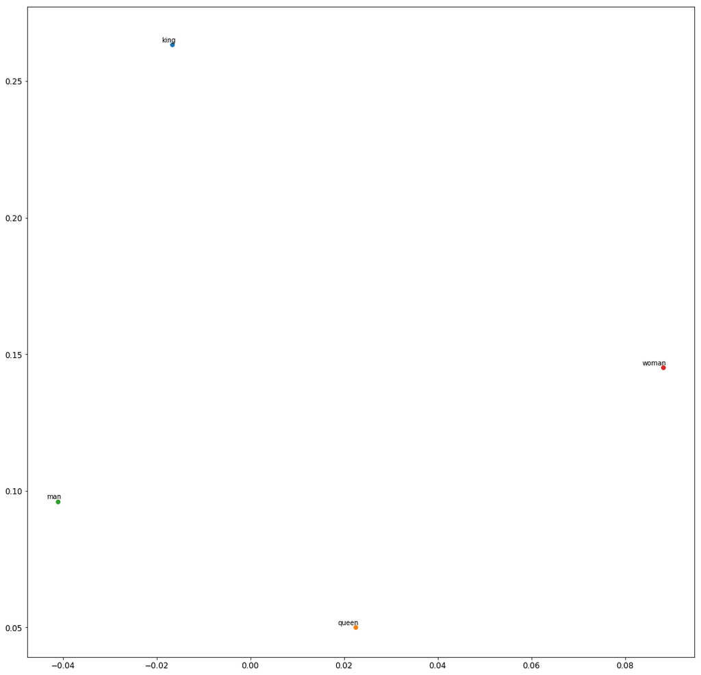

```python
from sklearn.decomposition import PCA

pca = PCA(n_components=2)
plot_only = 500
low_dim_embs = pca.fit_transform(final_embeddings[:plot_only,:])
#labels = [vocabulary[i] for i in range(plot_only,600)]

labels = ['king','queen','man','woman']
#labels = ['russia','england','norway','usa','turkey','moscow','london','washington','ankara','oslo']
plot_with_labels(low_dim_embs, labels)
```